# Homework: sp and sf

Matt RIng

9/19/2021

## Overview

In this exercise, you will explore US census tract data in Washington D.C and the surrounding states.

You will be working in two files as you complete this homework, your own script file, and this R markdown file, which you will be editing and adding to. You will submit this R Markdown file (modified as described below) and your R script file.

When I create an R Markdown file to communicate a coding process, I usually work in a .R script file and copy-and-paste the code into the R Markdown document at the end.

**Important**

- To receive full credit for a given question, please ensure that the result you provide **only** answers the given question. For example, in the table below, if you were asked to determine the value in column `b` where column `a` is equal to “hello” you would provide the following code:

```r
tibble(
  a = c('hello', 'world'),
  b = 1:2) %>%
  filter(a == 'hello') %>%
  pull(b)
```

```
## [1] 1
```

## Getting started

If you haven’t already, please start by knitting this file.

Next, create a new folder in your R Studio project folder: `data/raw/spatial/census`.

After you have created your folder, download all of the files in our Canvas data folder that start with the word “census” (there will be four files) and save those files to your newly created folder.

Open R Studio. Please ensure that the Global Options for R Markdown are set to “Show output preview in Viewer Pane”. This will allow you to view the knitted document (i.e., the html version of this file) right next to your code.

**Please note: For R Markdown to work properly this file must be placed in the top level of your project folder!**

Please ensure that you are starting with a clean session. Do the following before continuing:

1. If there are any script files open in your source pane. Close them. If any of the file titles are blue, save them prior to closing.
2. In the *Environment* tab of your **workspace pane**, ensure that your **global environment** is empty. If it is not, click the *broom* to remove all objects.
3. In the *History* tab of your **workspace pane**, ensure that your history is empty. If it is not, click the *broom* to remove your history.

Create a script file:

1. Open a new script file.
2. Save the file right away. Please save it as the following, but **replace my name with yours**: `scripts/homework_2_Brian_Evans.R`.
3. Add a new code section and call it “setup”
4. After a space between your section break, include and run the following:

```r
library(tidyverse)
library(sf)
```

## Read in the data

1. [0.5 points] Read the `census.shp` file (and its friends along the way!) into your global environment, assigning the name `census_sp`. In your script file, be sure to include a comment that describes the file that you are reading in. Copy-and-paste your code into the code chunk below.

```r
# Reads in the census shapefile
census_sp <-
  rgdal::readOGR('data/raw/spatial/census/census.shp')
```

2. [0.5 points] Let’s start by exploring our the coordinate reference system (CRS). What is the proj4string for these data?

```r
# Outputs the coordinate reference system for these data
census_sp@proj4string
```

```
## CRS arguments: +proj=longlat +datum=NAD83 +no_defs
```

3. [0.5 points] Is this a projected or geographic coordinate system?

4. [1.0 points] The datum for this CRS is the “North American Datum 1983”. Would you expect the spatial accuracy (i.e., how close a location is to its true location) of points in North America using this datum to be higher, lower, or the same as the spatial accuracy of WGS84? Why?

**Answer:** I would expect NAD83 to have a higher accuracy for points in North America than WGS84. This is because NAD83 is constructed for use specifically in North America whereas WGS83 is designed to be used for the entire world.

5. [0.5 points] Subset the data such that you create a separate SpatialPointsDataFrame for each individual state (District of Columbia as a state here!). Assign the objects to your global environment using the names `dc_sp`, `md_sp`, and `va_sp` (*Note: Note: If you are comfortable with for loops or purrr and using lists, this would be a good use for it! If not, you don’t have to use them here.*):

```r
# Separates the data by state
dc_sp <- census_sp[census_sp$state_name == "DC",]

md_sp <- census_sp[census_sp$state_name == "Maryland",]

va_sp <- census_sp[census_sp$state_name == "Virginia",]
```

6. [0.5 points] What is the spatial extent of each state?

```r
# Determines the spatial extent of each state

# DC's area (Land & Water)
sum(dc_sp$ALAND) + sum(dc_sp$AWATER)
```

```
## [1] 177027585
```

```r
# Maryland's area (Land & Water)
sum(md_sp$ALAND) + sum(md_sp$AWATER)
```

```
## [1] 32131067266
```

```r
# Virginia's area (Land & Water)
sum(va_sp$ALAND) + sum(va_sp$AWATER)
```

```
## [1] 110786248957
```

7. [0.5 points] Plot dc_sp:

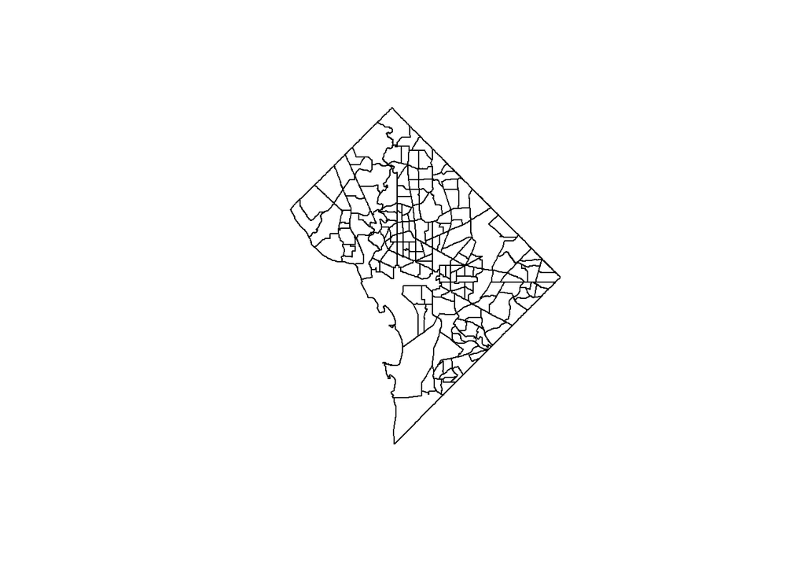

```r
# Plots DC

sp::plot(dc_sp)
```

8. [0.5 points] Create a shapefile of the state of Virginia by dissolving the census tract boundaries for that state:

```r
# Dissolves census tract boundaries in Virginia

# Note: Creates a weird boundary whereby VA's claim to Delmarva is connected to
# mainland VA. Not sure how to get rid of this, even tried using sf.
va_dsslvd <- rgeos::gUnaryUnion(va_sp)
```

9. [0.5 points] Plot the state of Virginia:

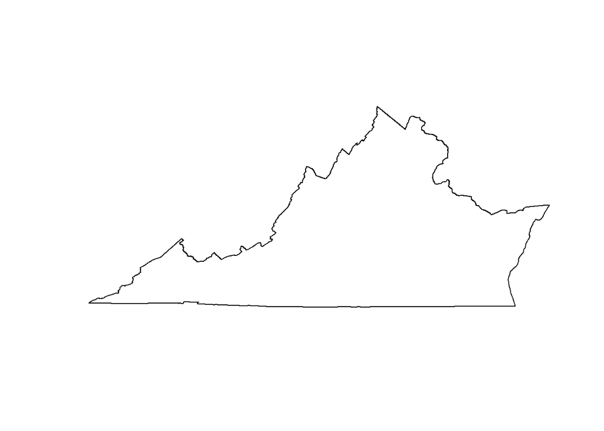

```r
# Plots VA using sp
sp::plot(va_dsslvd)
```

10. [1.0 points] Using a handheld gps unit set to record points in **WGS84**, our classroom is located at a latitude of 38.90677 and a longitude of -77.075212. Using this information, create a SpatialPoints object (with just one point; see `?SpatialPoints`). Assign the name `classroom_sp` to the resultant object.

*Please note: The proj4string for WGS84 can be specified as “+proj=longlat +datum=WGS84”.*

```r
# Creates a point object for our classroom
classroom_sp <- sp::SpatialPoints(cbind(-77.075212, 38.90677),
                                  proj4string = sp::CRS("+proj=longlat +datum=WGS84"))
```

11. [0.5 points] Convert the DC shapefile, `dc_sp`, to a simple features object and assign the object to your global environment with the name `dc_sf`:

```r
# Changes "dc_sp" to "dc_sf" (a simple features object)
dc_sf <- dc_sp %>%
  st_as_sf()
```

12. [0.5 points] Convert your `classroom_sp` file to a simple features object and assign the object to your global environment with the name `classroom_sf`:

```r
# Changes the classroom point to a simple features object
classroom_sf <- classroom_sp %>%
  st_as_sf()
```

13. [1.0 points] Use a spatial join (`classroom_sf` and `dc_sf`) to determine the number of people that live in Georgetown’s census tract (*Hint: You should modify your point data **before** joining the data!*):

```r
# Changes the classroom point's crs to NAD83
classroom_prj <- classroom_sf %>%
  st_transform(
    st_crs(dc_sf))

# Finds the population of the census tract for our classroom
classroom_prj %>%
  st_join(dc_sf) %>%
  pull(population)
```

```
## [1] 4074
```

14. [1.0 points] Using ggPlot, plot the `dc_sf` census tract data such that the fill color of each census tract corresponds to the level of education attainment in that within the census tract (*Note: the column “edu” refers to the proportion of the population with at least an Associate degree*). Additionally:
    1. [0.5 points] Add the location of our classroom as a point on the map.
    2. [0.5 points] Please modify a minimum of three out of the seven grammar of graphics data visualization elements.

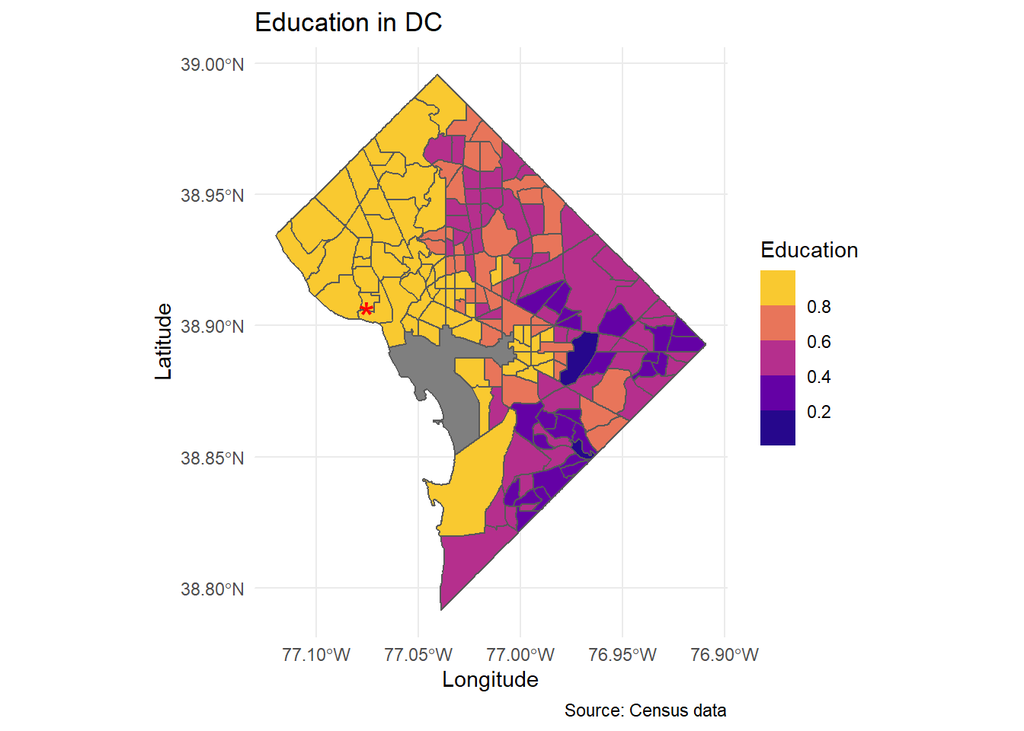

```r
# Plots education levels in DC & adds a point for our classroom
dc_sf %>%
  ggplot() +
  # Adds in the education data as fill color for each tract
  geom_sf(aes(fill = edu)) +
  # Adds the classroom point, changes its color, shape, size
  stat_sf_coordinates(data = classroom_prj, color = "red",
                      shape = "*", size = 7) +
  # Changes the color scale to viridis's plasma option
  scale_fill_viridis_b(option = "plasma") +
  # Adds labels
  labs(title = "Education in DC",
       fill = "Education",
       x = "Longitude",
       y = "Latitude",
       caption = "Source: Census data") +
  # Sets the theme to minimal
  theme_minimal()
```

## Submission

Save this document and your R script file in your project folder and submit both files to Canvas